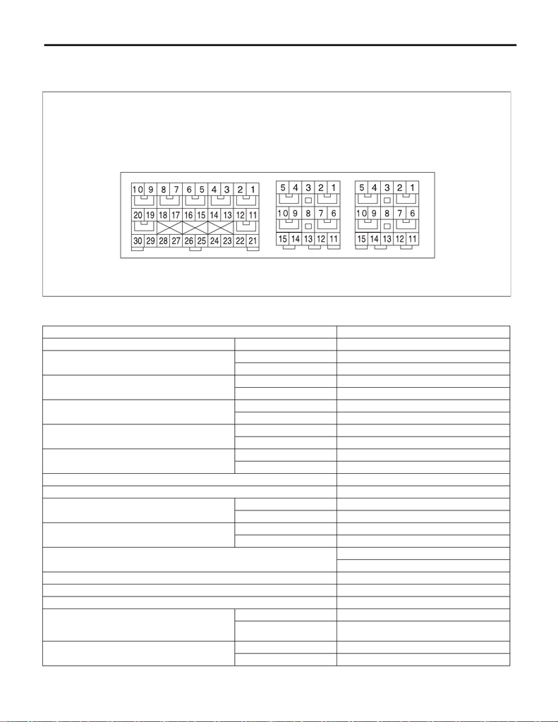

6. Airbag Control Module I/O Signal

A: ELECTRICAL SPECIFICATION

• Terminal numbers in airbag control module connector are shown in the figure.

• The airbag warning light illuminates when the connector is removed from the airbag control module.

Item Control module terminal No.

Ignition power supply Dedicated fuse (1) — 21

Passenger’s airbag module level one + (1) — 4

– (1) — 3

Passenger’s airbag module level two + (1) — 1

– (1) — 2

Driver’s airbag module level one + (1) — 5

– (1) — 6

Driver’s airbag module level two + (1) — 8

– (1) — 7

Driver’s knee airbag module + (1) — 9

–(1) — 10

CAN-H (1) — 13

CAN-L (1) — 22

Front sub sensor LH + (1) — 30

–(1) — 28

Front sub sensor RH + (1) — 29

–(1) — 27

Ground line (GND) (1) — 25

(1) — 26

Passenger’s airbag OFF indicator (1) — 17

Passenger’s airbag ON indicator (1) — 23

Passenger’s seat belt warning (1) — 15

Side airbag sensor LH

Curtain airbag sensor LH

Front door impact sensor LH

+ (2) — 8

–

(2) — 15

Side airbag module LH + (2) — 9

–(2) — 10

(1) (2) (3)

[figure not shown]

Curtain airbag module LH + (2) — 7

– (2) — 6

Seat belt pretensioner LH + (2) — 2

– (2) — 1

Satellite safing sensor + (3) — 15

–(3) — 14

Seat belt pretensioner RH + (3) — 4

– (3) — 5

Lap seat belt pretensioner RH + (3) — 1

– (3) — 2

Side airbag sensor RH

Curtain airbag sensor RH

Front door impact sensor RH

+ (3) — 8

–

(3) — 11

Side airbag module RH + (3) — 7

– (3) — 6

Curtain airbag module RH + (3) — 9

–(3) — 10

Occupant detection control module + (3) — 12

–(3) — 13